# Tutorial 2b

sven panis

2025-11-25

In this Tutorial 2b we fit a Bayesian multilevel model to the conditional accuracy data, using the input file created in Tutorial 1a.

# 1. Load the libraries that we will be using.

```r
pkg <- c(
  "cmdstanr", "standist", "tidyverse", "RColorBrewer", "patchwork",
  "brms", "tidybayes", "bayesplot", "future", "parallel", "modelr",
  "rstan"
)

lapply(pkg, library, character.only = TRUE)
```

```
## This is cmdstanr version 0.9.0.9000
```

```
## - CmdStanR documentation and vignettes: mc-stan.org/cmdstanr
```

```
## - CmdStan path: /Users/spanis/.cmdstan/cmdstan-2.36.0
```

```
## - CmdStan version: 2.36.0
```

```
##
## A newer version of CmdStan is available. See ?install_cmdstan() to install it.
## To disable this check set option or environment variable cmdstanr_no_ver_check=TRUE.
```

[output not shown]

Set options.

```r
options(
  brms.backend = "cmdstanr",
  mc.cores = parallel::detectCores(),
  future.fork.enable = TRUE,
  future.rng.onMisuse = "ignore"
) ## automatically set in RStudio

supportsMulticore()
detectCores()
```

```r
packageVersion("cmdstanr")
devtools::session_info("rstan")
```

theme settings for ggplot

```r
theme_set(
  theme_bw() +
    theme(
      text = element_text(size = 22, face = "bold"),
      title = element_text(size = 22, face = "bold"),
      legend.position = "bottom"
    )
)

## Set the amount of dodge in figures
pd <- position_dodge(0.7)
pd2 <- position_dodge(1)
```

# 2. Load and wrangle the person-trial data set.

```r
ca_data <- read_csv("Tutorial_1_descriptive_stats/data/inputfile_ca_modeling.csv")
head(ca_data)
```

Prepare the data set.

```r
# select analysis time range: (200,600]
ca_data <- ca_data |>
  filter(drt > 5) |>
  # create factor condition, with "blank" as the reference level
  mutate(
    condition = factor(condition,
      labels = c("blank", "congruent", "incongruent")
    ),
    prime = ifelse(condition == "blank", 1,
      ifelse(condition == "congruent", 2, 3)
    ),
    prime = factor(prime, levels = c(1, 2, 3)),
    timebin = factor(drt, levels = c(6:15)),
    period_9 = drt - 9,
    trial_c = (trial - 1000) / 1000
  )
head(ca_data)
```

```
## # A tibble: 6 × 11
##     pid    bl    tr trial condition     acc   drt prime timebin period_9 trial_c
##   <dbl> <dbl> <dbl> <dbl> <fct>       <dbl> <dbl> <fct> <fct>      <dbl>   <dbl>
## 1     1     2     4     4 congruent       1    12 2     12             3  -0.996
## 2     1     2     5     5 incongruent     1    15 3     15             6  -0.995
## 3     1     2    15    15 congruent       1    14 2     14             5  -0.985
## 4     1     2    17    17 incongruent     1    15 3     15             6  -0.983
## 5     1     3     7    29 congruent       1    12 2     12             3  -0.971
## 6     1     3    11    33 incongruent     1    13 3     13             4  -0.967
```

# 3. Fit a conditional accuracy model.

We fit a single model “M1i_ca”, using index coding for both TIME and condition (variables “timebin” and “prime” in ca_data).

## Prepare data for M1i_ca.

```r
# remove unnecessary columns before fitting a model
data_M1i_ca <- ca_data |>
  select(pid, acc, timebin, prime)
head(data_M1i_ca)
```

```
## # A tibble: 6 × 4
##     pid   acc timebin prime
##   <dbl> <dbl> <fct>   <fct>
## 1     1     1 12      2
## 2     1     1 15      3
## 3     1     1 14      2
## 4     1     1 15      3
## 5     1     1 12      2
## 6     1     1 13      3
```

## Set up priors for M1i_ca.

As we expect conditional accuracies ranging between (and including) 0 and 1, we use a flat prior on the logit scale for our intercepts (see Supplementary Figure 8 in section H of the Supplemental Material).

```r
priors_M1i_ca <- c(
  set_prior("student_t(7.61, 0, 1.57)", class = "b"), # use flat prior on logit scale for the proportion ca
  set_prior("normal(0, 1)", class = "sd"),
  set_prior("lkj(2)", class = "cor")
)
```

## Fit model M1i_ca.

```r
plan(multicore)

model_M1i_ca <-
  brm(
    data = data_M1i_ca,
    family = bernoulli(link = "logit"), # use logit link for conditional accuracy
    formula = acc ~ 0 + timebin:prime +
      (0 + timebin:prime | pid),
    prior = priors_M1i_ca,
    chains = 4, cores = 4, iter = 3000, warmup = 1000,
    control = list(adapt_delta = 0.999, step_size = 0.04, max_treedepth = 14),
    seed = 12, init = "0",
    file = "Tutorial_2_Bayesian/models/model_M1i_ca"
  )
```

Model_M1i_ca took about 11 minutes to run on a MacBook Pro (Sonoma 14.6.1 OS, 18GB Memory, M3 Pro Chip).

```r
model_M1i_ca <- readRDS("Tutorial_2_Bayesian/models/model_M1i_ca.rds")
fixef(model_M1i_ca)
```

```
##                    Estimate Est.Error       Q2.5      Q97.5
## timebin6:prime1   0.5835765 0.9027177 -1.1365807  2.4307320
## timebin7:prime1   0.7043138 0.5175843 -0.3737397  1.7133458
## timebin8:prime1   1.6985721 0.4340042  0.7935488  2.5553350
## timebin9:prime1   2.5742291 0.5112676  1.5179200  3.5922035
## timebin10:prime1  4.5051095 0.7072520  3.2195493  6.0491657
## timebin11:prime1  4.8813988 0.9499587  3.3161795  7.0353075
## timebin12:prime1  5.2894339 1.5495291  3.0364593  9.0707580
## timebin13:prime1  4.5334870 1.5157782  2.3134445  8.2649535
## timebin14:prime1  3.5523579 1.4433336  1.3603038  7.0711740
## timebin15:prime1  2.6737311 1.3886284  0.4719077  5.9063265
## timebin6:prime2   4.8367380 1.5648361  2.6464340  8.6150377
## timebin7:prime2   4.3666984 0.9288508  2.7702440  6.4496005
## timebin8:prime2   5.6561387 1.6482857  3.4086047  9.6245200
## timebin9:prime2   5.8764474 1.7701990  3.5667185  9.9302813
## timebin10:prime2  5.3298176 1.6162074  3.0471345  9.1528960
## timebin11:prime2  3.6334303 0.9537159  1.9777077  5.7543465
## timebin12:prime2  4.2033900 1.4578439  2.0651035  7.7880325
## timebin13:prime2  3.4114247 1.4197493  1.2722955  6.8195637
## timebin14:prime2  1.3244849 1.0158070 -0.4889263  3.4863447
## timebin15:prime2  2.1584388 1.4638749 -0.2597691  5.5557480
## timebin6:prime3  -4.8294356 1.5354250 -8.5665905 -2.5979753
## timebin7:prime3  -4.9128130 1.5293350 -8.6394870 -2.6523593
## timebin8:prime3  -2.0680508 0.8898860 -3.8977465 -0.3355925
## timebin9:prime3   1.0517892 0.8796570 -0.6649911  2.8020900
## timebin10:prime3  3.4772914 0.9048086  1.5952645  5.2673882
## timebin11:prime3  3.7358227 0.7475934  2.4137682  5.3574575
## timebin12:prime3  5.2786858 1.6350859  3.0197233  9.2151635
## timebin13:prime3  4.8223087 1.5821494  2.5973865  8.7851205
## timebin14:prime3  4.1947970 1.4470645  2.0600320  7.5805285
## timebin15:prime3  1.5391906 0.7782289  0.1240576  3.1887192
```

# 4. Display effects for the conditional accuracy model.

## Pareto k estimates

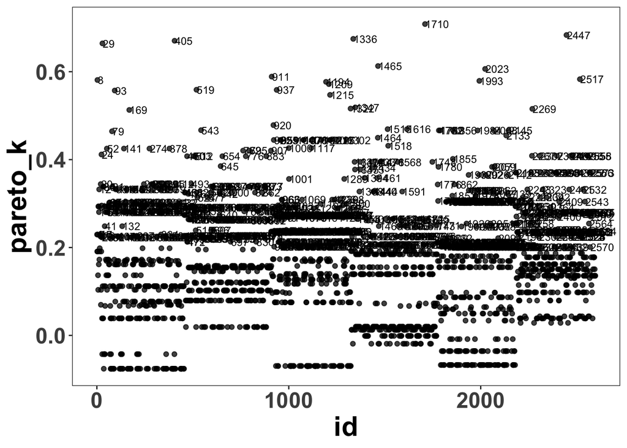

```r
loo(model_M1i_ca)$diagnostics |>
  data.frame() |>
  # attach the `id` values
  bind_cols(data_M1i_ca) |>
  mutate(id = 1:n()) |>
  ggplot(aes(x = id, y = pareto_k)) +
  geom_point(alpha = 3 / 4) +
  geom_text(
    data = . %>% filter(pareto_k > .2),
    aes(x = id + 2, label = id),
    size = 3, hjust = 0
  ) +
  theme(panel.grid = element_blank())
```

## Plot posterior distributions for M1i_ca.

Wrangle the posterior draws.

```r
post_ca <- as_draws_df(model_M1i_ca) |>
  select(-lp__) |>
  as_tibble()

post_summary <- posterior_summary(model_M1i_ca, robust = TRUE)
post_summary[1:30, ]
```

```
##                      Estimate Est.Error       Q2.5      Q97.5
## b_timebin6:prime1   0.5674505 0.8723026 -1.1365807  2.4307320
## b_timebin7:prime1   0.7096565 0.4707307 -0.3737397  1.7133458
## b_timebin8:prime1   1.7047250 0.3821772  0.7935488  2.5553350
## b_timebin9:prime1   2.5777650 0.4509402  1.5179200  3.5922035
## b_timebin10:prime1  4.4653950 0.6432334  3.2195493  6.0491657
## b_timebin11:prime1  4.7773100 0.8757866  3.3161795  7.0353075
## b_timebin12:prime1  5.0183750 1.2926270  3.0364593  9.0707580
## b_timebin13:prime1  4.2830050 1.2758218  2.3134445  8.2649535
## b_timebin14:prime1  3.3267850 1.2380451  1.3603038  7.0711740
## b_timebin15:prime1  2.5205300 1.2271851  0.4719077  5.9063265
## b_timebin6:prime2   4.5718750 1.2889428  2.6464340  8.6150377
## b_timebin7:prime2   4.2861550 0.8460086  2.7702440  6.4496005
## b_timebin8:prime2   5.3789250 1.3103515  3.4086047  9.6245200
## b_timebin9:prime2   5.5742000 1.3264229  3.5667185  9.9302813
## b_timebin10:prime2  5.0537400 1.3112930  3.0471345  9.1528960
## b_timebin11:prime2  3.5518800 0.8711387  1.9777077  5.7543465
## b_timebin12:prime2  3.9628100 1.2604769  2.0651035  7.7880325
## b_timebin13:prime2  3.1984600 1.2412772  1.2722955  6.8195637
## b_timebin14:prime2  1.2519150 0.9578041 -0.4889263  3.4863447
## b_timebin15:prime2  1.9930450 1.3071714 -0.2597691  5.5557480
## b_timebin6:prime3  -4.5731800 1.2878605 -8.5665905 -2.5979753
## b_timebin7:prime3  -4.6591700 1.3058667 -8.6394870 -2.6523593
## b_timebin8:prime3  -2.0473250 0.8155634 -3.8977465 -0.3355925
## b_timebin9:prime3   1.0349500 0.8263449 -0.6649911  2.8020900
## b_timebin10:prime3  3.4896100 0.8191068  1.5952645  5.2673882
## b_timebin11:prime3  3.6778650 0.7028710  2.4137682  5.3574575
## b_timebin12:prime3  4.9929150 1.3220567  3.0197233  9.2151635
## b_timebin13:prime3  4.5455250 1.2939836  2.5973865  8.7851205
## b_timebin14:prime3  3.9869850 1.2814631  2.0600320  7.5805285
## b_timebin15:prime3  1.4837250 0.7343288  0.1240576  3.1887192
```

```r
post_qi_b <- post_ca |>
  select(starts_with("b_")) |>
  pivot_longer(everything()) |>
  group_by(name) |>
  median_qi(value) |>
  arrange(name)
head(post_qi_b) # 30 "fixed" effects
```

```
## # A tibble: 6 × 7
##   name               value .lower .upper .width .point .interval
##   <chr>              <dbl>  <dbl>  <dbl>  <dbl> <chr>  <chr>
## 1 b_timebin10:prime1  4.47   3.22   6.05   0.95 median qi
## 2 b_timebin10:prime2  5.05   3.05   9.15   0.95 median qi
## 3 b_timebin10:prime3  3.49   1.60   5.27   0.95 median qi
## 4 b_timebin11:prime1  4.78   3.32   7.04   0.95 median qi
## 5 b_timebin11:prime2  3.55   1.98   5.75   0.95 median qi
## 6 b_timebin11:prime3  3.68   2.41   5.36   0.95 median qi
```

Visualise fixed effects.

```r
tidy_fixed_ca <- post_ca |>
  select(starts_with("b_"), .chain, .iteration, .draw) |>
  rename(chain = .chain, iter = .iteration, draw = .draw) |>
  pivot_longer(-c(chain, draw, iter)) |>
  mutate(
    timebin = str_sub(name, 10, 11),
    timebin = factor(str_remove(timebin, ":"), levels = c(6:15)),
    condition = str_sub(name, 17, 18),
    condition = factor(str_remove(condition, "e"),
      levels = c(1, 2, 3),
      labels = c("blank", "congruent", "incongruent")
    )
  )
head(tidy_fixed_ca)
```

```
## # A tibble: 6 × 7
##   chain  iter  draw name                value timebin condition
##   <int> <int> <int> <chr>               <dbl> <fct>   <fct>
## 1     1     1     1 b_timebin6:prime1  -1.31  6       blank
## 2     1     1     1 b_timebin7:prime1   0.926 7       blank
## 3     1     1     1 b_timebin8:prime1   2.19  8       blank
## 4     1     1     1 b_timebin9:prime1   2.27  9       blank
## 5     1     1     1 b_timebin10:prime1  5.17  10      blank
## 6     1     1     1 b_timebin11:prime1  4.53  11      blank
```

```r
tail(tidy_fixed_ca)
```

```
## # A tibble: 6 × 7
##   chain  iter  draw name               value timebin condition
##   <int> <int> <int> <chr>              <dbl> <fct>   <fct>
## 1     4  2000  8000 b_timebin10:prime3 0.593 10      incongruent
## 2     4  2000  8000 b_timebin11:prime3 3.40  11      incongruent
## 3     4  2000  8000 b_timebin12:prime3 4.42  12      incongruent
## 4     4  2000  8000 b_timebin13:prime3 6.36  13      incongruent
## 5     4  2000  8000 b_timebin14:prime3 4.25  14      incongruent
## 6     4  2000  8000 b_timebin15:prime3 2.02  15      incongruent
```

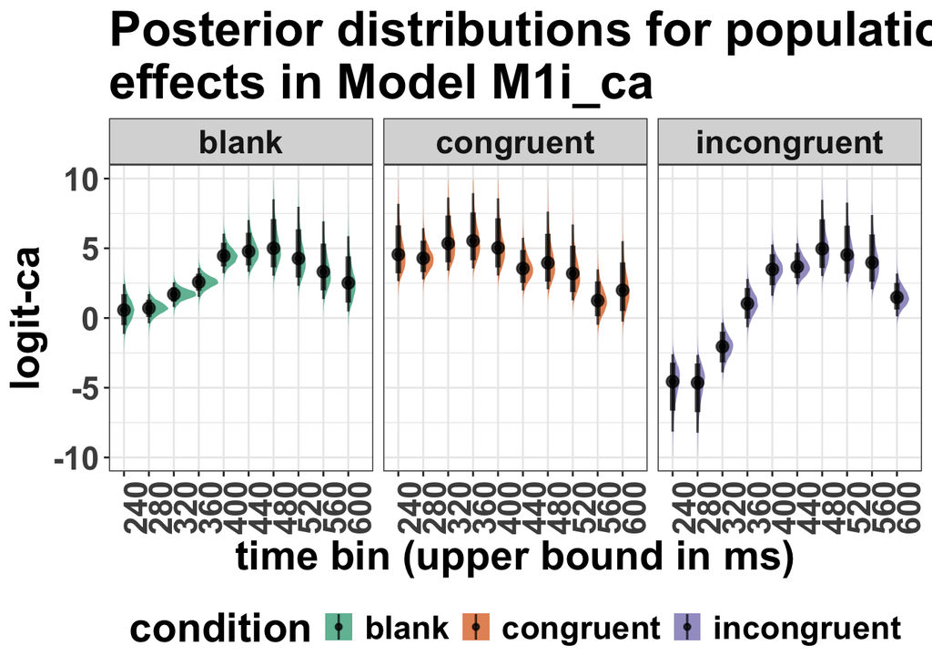

```r
# plot
p_tidy_fixed_ca <- ggplot(tidy_fixed_ca, aes(x = timebin, y = value, fill = condition)) +
  stat_halfeye(
    point_interval = "median_qi",
    .width = c(.80, .95),
    alpha = 0.7
  ) +
  labs(
    title = "Posterior distributions for population-level\neffects in Model M1i_ca",
    x = "time bin (upper bound in ms)",
    y = "logit-ca"
  ) +
  scale_fill_brewer(palette = "Dark2") +
  scale_x_discrete(labels = c(6:15) * 40, breaks = 6:15) +
  scale_y_continuous(limits = c(-10, 10)) +
  theme(axis.text.x = element_text(angle = 90)) +
  facet_wrap(~condition)
p_tidy_fixed_ca
```

```r
ggsave("Tutorial_2_Bayesian/figures/M1i_ca_postdistr.png", width = 10, height = 8, dpi = 800)
```

## Plot predicted conditional accuracy functions

### Grand mean

```r
dat_M1i_ca <- as_tibble(model_M1i_ca$data)

epreds_grand <- dat_M1i_ca |>
  data_grid(timebin, prime) |>
  add_epred_draws(model_M1i_ca,
    re_formula = NA
  ) |>
  mutate(prime = factor(prime,
    levels = c(1, 2, 3),
    labels = c("blank", "congruent", "incongruent")
  )) |>
  ungroup()
```

Summarize and plot predicted hazard values.

```r
epreds_grand |>
  group_by(timebin, prime) |>
  median_qi()
```

```
## # A tibble: 30 × 8
##    timebin prime        .epred   .lower .upper .width .point .interval
##    <fct>   <fct>         <dbl>    <dbl>  <dbl>  <dbl> <chr>  <chr>
##  1 6       blank       0.638   0.243    0.919    0.95 median qi
##  2 6       congruent   0.990   0.934    1.00     0.95 median qi
##  3 6       incongruent 0.0102  0.000190 0.0693   0.95 median qi
##  4 7       blank       0.670   0.408    0.847    0.95 median qi
##  5 7       congruent   0.986   0.941    0.998    0.95 median qi
##  6 7       incongruent 0.00939 0.000177 0.0658   0.95 median qi
##  7 8       blank       0.846   0.689    0.928    0.95 median qi
##  8 8       congruent   0.995   0.968    1.00     0.95 median qi
##  9 8       incongruent 0.114   0.0199   0.417    0.95 median qi
## 10 9       blank       0.929   0.820    0.973    0.95 median qi
## # ℹ 20 more rows
```

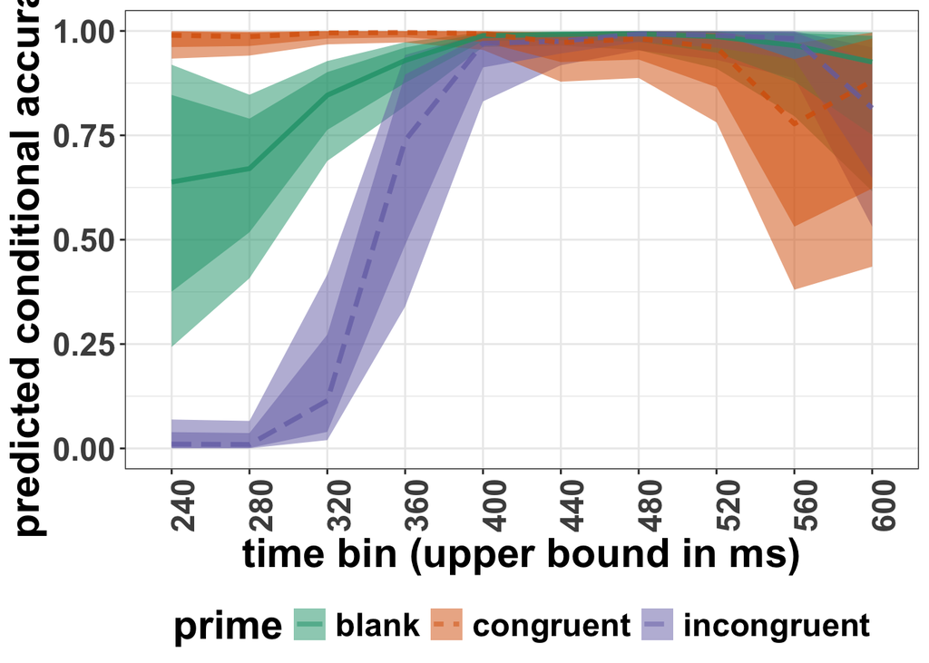

```r
p1 <- ggplot(epreds_grand, aes(
  x = timebin, y = .epred,
  fill = prime, color = prime
)) +
  stat_lineribbon(aes(linetype = prime),
    point_interval = "median_qi",
    alpha = 0.5,
    .width = c(.8, .95)
  ) +
  scale_fill_brewer(palette = "Dark2") +
  scale_color_brewer(palette = "Dark2") +
  scale_x_discrete(labels = c(6:15) * 40, breaks = 6:15) +
  theme(axis.text.x = element_text(angle = 90)) +
  scale_y_continuous(limits = c(0, 1)) +
  labs(
    x = "time bin (upper bound in ms)",
    y = "predicted conditional accuracy"
  )

p1
```

### Subject-specific

```r
epreds_pid <- dat_M1i_ca |>
  data_grid(pid, timebin, prime) |>
  add_epred_draws(model_M1i_ca,
    re_formula = NULL
  ) |>
  mutate(prime = factor(prime,
    levels = c(1, 2, 3),
    labels = c("blank", "congruent", "incongruent")
  )) |>
  ungroup()
```

Summarize and plot predicted hazard values.

```r
epreds_pid |>
  group_by(pid, timebin, prime) |>
  median_qi()
```

```
## # A tibble: 180 × 9
##      pid timebin prime        .epred   .lower .upper .width .point .interval
##    <dbl> <fct>   <fct>         <dbl>    <dbl>  <dbl>  <dbl> <chr>  <chr>
##  1     1 6       blank       0.644   0.251    0.930    0.95 median qi
##  2     1 6       congruent   0.991   0.928    1.00     0.95 median qi
##  3     1 6       incongruent 0.00889 0.000124 0.0728   0.95 median qi
##  4     1 7       blank       0.841   0.623    0.970    0.95 median qi
##  5     1 7       congruent   0.988   0.941    0.999    0.95 median qi
##  6     1 7       incongruent 0.00811 0.000124 0.0676   0.95 median qi
##  7     1 8       blank       0.910   0.819    0.970    0.95 median qi
##  8     1 8       congruent   0.996   0.966    1.00     0.95 median qi
##  9     1 8       incongruent 0.139   0.0197   0.552    0.95 median qi
## 10     1 9       blank       0.879   0.784    0.940    0.95 median qi
## # ℹ 170 more rows
```

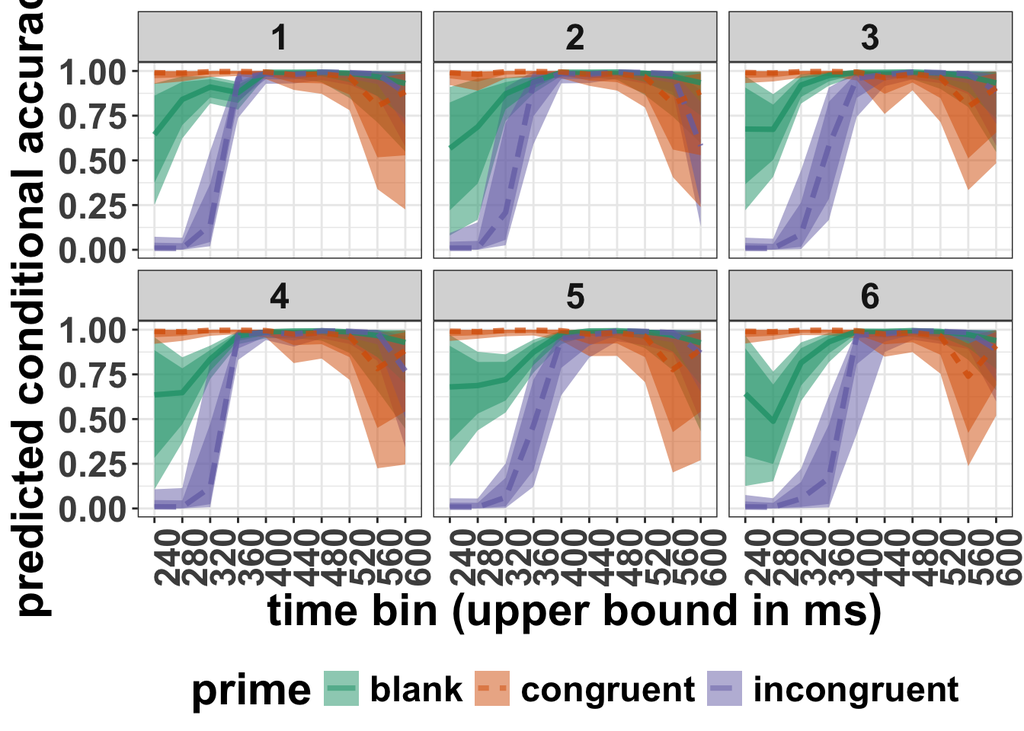

```r
p2 <- ggplot(epreds_pid, aes(
  x = timebin, y = .epred,
  fill = prime, color = prime
)) +
  stat_lineribbon(aes(linetype = prime),
    point_interval = "median_qi",
    alpha = 0.5,
    .width = c(.8, .95)
  ) +
  scale_fill_brewer(palette = "Dark2") +
  scale_color_brewer(palette = "Dark2") +
  scale_x_discrete(labels = c(6:15) * 40, breaks = 6:15) +
  theme(axis.text.x = element_text(angle = 90)) +
  scale_y_continuous(limits = c(0, 1)) +
  labs(
    x = "time bin (upper bound in ms)",
    y = "predicted conditional accuracy"
  ) +
  facet_wrap(~pid, ncol = 3)
p2
```

Combine the plots.

```r
# combine 2 plots
p1_theme <- p1 + theme(legend.position = "none")

(p1_theme / p2) +
  plot_annotation(tag_levels = "A") +
  plot_layout(
    guides = "collect",
    axes = "collect_x"
  ) &
  theme(legend.position = "bottom")
```

Save combined plot.

```r
# save combined plot
ggsave("Tutorial_2_Bayesian/figures/M1i_ca_pred_combined.png", width = 10, height = 12, dpi = 800)
```

## Plot average marginal effects (AMEs)

See Heiss (2021).

### Grand mean AMEs

```r
epreds_grand_diffs <- epreds_grand |>
  pivot_wider(
    id_cols = c(timebin, .draw),
    names_from = "prime",
    values_from = ".epred"
  ) |> # 80000 x 5
  mutate(
    `congruent minus blank` = congruent - blank,
    `incongruent minus blank` = incongruent - blank
  ) |>
  select(-c(blank, congruent, incongruent)) |>
  pivot_longer(
    cols = c(`congruent minus blank`, `incongruent minus blank`),
    names_to = "contrast",
    values_to = "diff_ca"
  )

epreds_grand_diffs # 160 000 rows
```

```
## # A tibble: 160,000 × 4
##    timebin .draw contrast                diff_ca
##    <fct>   <int> <chr>                     <dbl>
##  1 6           1 congruent minus blank     0.781
##  2 6           1 incongruent minus blank  -0.202
##  3 6           2 congruent minus blank     0.229
##  4 6           2 incongruent minus blank  -0.709
##  5 6           3 congruent minus blank     0.522
##  6 6           3 incongruent minus blank  -0.430
##  7 6           4 congruent minus blank     0.593
##  8 6           4 incongruent minus blank  -0.389
##  9 6           5 congruent minus blank     0.199
## 10 6           5 incongruent minus blank  -0.749
## # ℹ 159,990 more rows
```

Summarize and plot.

```r
table <- epreds_grand_diffs |>
  group_by(contrast, timebin) |>
  mean_qi(.width = c(.95)) |>
  arrange(contrast, timebin, .width) |>
  select(-c(.width, .point, .interval))
```

```r
write_csv(table, file = "Tutorial_2_Bayesian/tables/ca_grand_AMEs.csv")
```

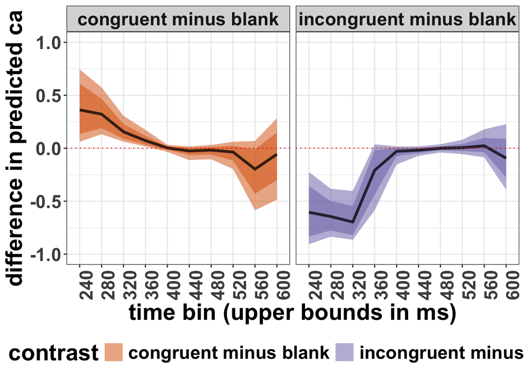

```r
p11 <- ggplot(epreds_grand_diffs, aes(
  x = timebin, y = diff_ca,
  fill = contrast
)) +
  stat_lineribbon(
    alpha = 0.5,
    point_interval = "mean_qi",
    .width = c(.8, .95)
  ) +
  geom_hline(
    yintercept = 0,
    color = "red",
    lty = 3
  ) +
  scale_y_continuous(limits = c(-1, 1)) +
  scale_x_discrete(labels = c(6:15) * 40, breaks = 6:15) +
  scale_fill_manual(values = c("#D95F02FF", "#7570B3FF")) +
  theme(axis.text.x = element_text(angle = 90)) +
  labs(
    x = "time bin (upper bounds in ms)",
    y = "difference in predicted ca"
  ) +
  facet_wrap(~contrast)

p11
```

### Subject-specific AMEs

To calculate the subject-specific AMEs for each time bin, we create contrasts between the conditional means.

```r
epreds_pid_diffs <- epreds_pid |>
  pivot_wider(
    id_cols = c(pid, timebin, .draw),
    names_from = "prime",
    values_from = ".epred"
  ) |> # 80000 x 5
  mutate(
    `congruent minus blank` = congruent - blank,
    `incongruent minus blank` = incongruent - blank
  ) |>
  select(-c(blank, congruent, incongruent)) |>
  pivot_longer(
    cols = c(`congruent minus blank`, `incongruent minus blank`),
    names_to = "contrast",
    values_to = "diff_ca"
  )

epreds_pid_diffs
```

```
## # A tibble: 960,000 × 5
##      pid timebin .draw contrast                diff_ca
##    <dbl> <fct>   <int> <chr>                     <dbl>
##  1     1 6           1 congruent minus blank     0.598
##  2     1 6           1 incongruent minus blank  -0.388
##  3     1 6           2 congruent minus blank     0.265
##  4     1 6           2 incongruent minus blank  -0.704
##  5     1 6           3 congruent minus blank     0.264
##  6     1 6           3 incongruent minus blank  -0.710
##  7     1 6           4 congruent minus blank     0.500
##  8     1 6           4 incongruent minus blank  -0.500
##  9     1 6           5 congruent minus blank     0.130
## 10     1 6           5 incongruent minus blank  -0.817
## # ℹ 959,990 more rows
```

Summarize and plot the contrasts in predicted hazard values.

```r
epreds_pid_diffs |>
  group_by(pid, timebin, contrast) |>
  mean_qi()
```

```
## # A tibble: 120 × 9
##      pid timebin contrast        diff_ca  .lower  .upper .width .point .interval
##    <dbl> <fct>   <chr>             <dbl>   <dbl>   <dbl>  <dbl> <chr>  <chr>
##  1     1 6       congruent min…  3.54e-1  0.0527  0.734    0.95 mean   qi
##  2     1 6       incongruent m… -6.13e-1 -0.918  -0.231    0.95 mean   qi
##  3     1 7       congruent min…  1.55e-1  0.0114  0.363    0.95 mean   qi
##  4     1 7       incongruent m… -8.13e-1 -0.959  -0.604    0.95 mean   qi
##  5     1 8       congruent min…  8.65e-2  0.0179  0.175    0.95 mean   qi
##  6     1 8       incongruent m… -7.27e-1 -0.912  -0.356    0.95 mean   qi
##  7     1 9       congruent min…  1.19e-1  0.0513  0.212    0.95 mean   qi
##  8     1 9       incongruent m…  5.65e-2 -0.148   0.184    0.95 mean   qi
##  9     1 10      congruent min… -6.42e-4 -0.0376  0.0234   0.95 mean   qi
## 10     1 10      incongruent m… -1.19e-2 -0.0648  0.0184   0.95 mean   qi
## # ℹ 110 more rows
```

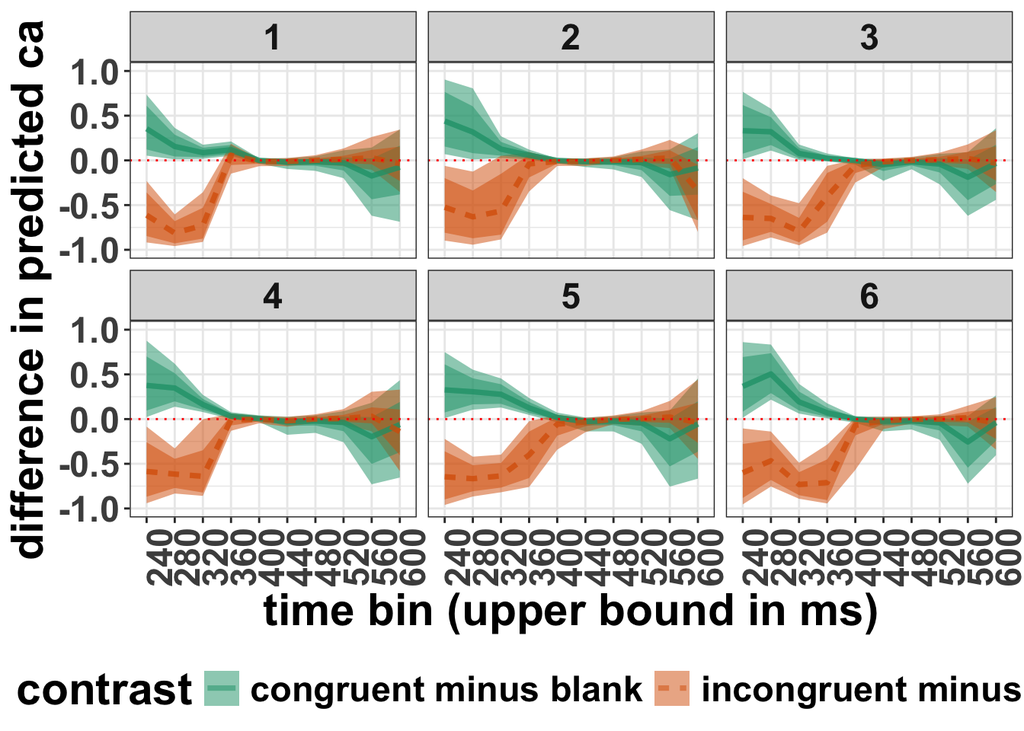

```r
p22 <- ggplot(epreds_pid_diffs, aes(
  x = timebin, y = diff_ca,
  fill = contrast, color = contrast
)) +
  stat_lineribbon(aes(linetype = contrast),
    alpha = 0.5,
    point_interval = "mean_qi",
    .width = c(.8, .95)
  ) +
  geom_hline(yintercept = 0, color = "red", lty = 3) +
  scale_fill_brewer(palette = "Dark2") +
  scale_color_brewer(palette = "Dark2") +
  scale_x_discrete(labels = c(6:15) * 40, breaks = 6:15) +
  theme(axis.text.x = element_text(angle = 90)) +
  scale_y_continuous(limits = c(-1, 1)) +
  labs(
    x = "time bin (upper bound in ms)",
    y = "difference in predicted ca"
  ) +
  facet_wrap(~pid, ncol = 3)
p22
```

Combine the plots.

```r
# combine 2 plots
p11_theme <- p11 + theme(legend.position = "none")

(p11_theme / p22) +
  plot_annotation(tag_levels = "A") +
  theme(legend.position = "bottom")
```

Save combined plot.

```r
# save combined plot
ggsave("Tutorial_2_Bayesian/figures/M1i_ca_ame_combined.png", width = 14, height = 12, dpi = 800)
```

## Create Figure for revised ms.

```r
# combine 3 plots
p11_theme <- p11 + theme(legend.position = "none")

(p_tidy_fixed_ca / p1 / p11) +
  plot_annotation(tag_levels = "A") +
  theme(legend.position = "bottom")
```

```r
ggsave("Tutorial_2_Bayesian/figures/Revision_results_ca.png", width = 14, height = 20, dpi = 800)
```

# 5. References.

Heiss, Andrew (2021). “A Guide to Correctly Calculating Posterior Predictions and Average Marginal Effects with Multilievel Bayesian Models.” November 10, 2021. https://doi.org/10.59350/wbn93-edb02.